# #Twitter

## 0.1 Preliminaries

# 1 Data Source

The source of my data is a .csv file obtained directly from the settings page of my personal twitter account (@McDonnellJack). I am heavily indebted to Julia Silge (@juliasilge) for sharing the basic code necessary for performing sentiment analysis and wrangling the date/time data with `lubridate`.

# 2 Load and Tidy the Data

```r
# load the .csv obtained from Twitter
tweets <- read.csv("./tweets.csv", stringsAsFactors = FALSE)

# use lubridate to convert time stamps to date/time objects
tweets$timestamp <- ymd_hms(tweets$timestamp)
tweets$timestamp <- with_tz(tweets$timestamp, "America/New_York")

# create a variable with time only (getting rid of month and year)
tweets$timeonly <- as.numeric(tweets$timestamp - trunc(tweets$timestamp, "days"))

# create a variable for type of tweet (tweet, retweet, reply)
tweets$type <- "tweet"
tweets[(!is.na(tweets$retweeted_status_id)),12] <- "RT"
tweets[(!is.na(tweets$in_reply_to_status_id)),12] <- "reply"
tweets$type <- as.factor(tweets$type)
tweets$type = factor(tweets$type,levels(tweets$type)[c(3,1,2)])

# create a variable for number of characters in each tweet
tweets$charsintweet <- sapply(tweets$text, function(x) nchar(x))

# remove handles from tweets in preparation for sentiment analysis
nohandles <- str_replace_all(tweets$text, "@\\w+", "")

# exclude useless variables
source <- names(tweets) %in% c("expanded_urls","timeonly","source", "V12")
tweets <- tweets[!source]

# create a data frame that will form the basis of my codebook (without sentiment analysis materials included)
# includes only 1000 observations, as dictated by the assignment
tweets.codebook <- tweets
set.seed(02202018)
tweets.codebook <- sample_n(tweets, size = 1000)

# convert text of my tweets into a form that can be analyzed by 'tm' package
wordCorpus <- Corpus(VectorSource(nohandles))
wordCorpus <- tm_map(wordCorpus, removePunctuation)
wordCorpus <- tm_map(wordCorpus, content_transformer(tolower))
wordCorpus <- tm_map(wordCorpus, removeWords, stopwords("english"))
wordCorpus <- tm_map(wordCorpus, removeWords, c("amp", "2yo", "3yo", "4yo"))
wordCorpus <- tm_map(wordCorpus, stripWhitespace)

# perform sentiment analysis
mySentiment <- get_nrc_sentiment(tweets$text)

# combine sentiment analysis with tweets data set
tweets <- cbind(tweets, mySentiment)

# compute a total sentiment score
sentimentTotals <- data.frame(colSums(tweets[,c(10:19)]))
names(sentimentTotals) <- "count"
sentimentTotals <- cbind("sentiment" = rownames(sentimentTotals), sentimentTotals)
rownames(sentimentTotals) <- NULL

# timestamp tweets to be able to analyze the sentiment as a function of time

tweets$timestamp <- with_tz(ymd_hms(tweets$timestamp), "America/New_York")
posnegtime <- tweets %>%
        group_by(timestamp = cut(timestamp, breaks="2 months")) %>%
        summarise(negative = mean(negative),
                  positive = mean(positive)) %>% melt
names(posnegtime) <- c("timestamp", "sentiment", "meanvalue")
posnegtime$sentiment = factor(posnegtime$sentiment,levels(posnegtime$sentiment)[c(2,1)])

# create new variable for considering tweet sentiment by weekday
tweets$weekday <- wday(tweets$timestamp, label = TRUE)
weeklysentiment <- tweets %>% group_by(weekday) %>%
        summarise(anger = mean(anger),
                  anticipation = mean(anticipation),
                  disgust = mean(disgust),
                  fear = mean(fear),
                  joy = mean(joy),
                  sadness = mean(sadness),
                  surprise = mean(surprise),
                  trust = mean(trust)) %>% melt
names(weeklysentiment) <- c("weekday", "sentiment", "meanvalue")

# create new variable for considering tweet sentiment by month
tweets$month <- month(tweets$timestamp, label = TRUE)
monthlysentiment <- tweets %>% group_by(month) %>%
        summarise(anger = mean(anger),
                  anticipation = mean(anticipation),
                  disgust = mean(disgust),
                  fear = mean(fear),
                  joy = mean(joy),
                  sadness = mean(sadness),
                  surprise = mean(surprise),
                  trust = mean(trust)) %>% melt
names(monthlysentiment) <- c("month", "sentiment", "meanvalue")

# create an indicator variable for whether or not "Trump" is mentioned in my tweet
tweets <- tweets %>% mutate(trump = ifelse(grepl("Trump", tweets$text) == T,1,0))

# obtain a sample of 1000, for both a full and codebook data frame
tweets_sample <- sample_n(tweets, size = 1000)

# set aside a test sample to be used later for model validation
tweets_sample_test <- anti_join(tweets, tweets_sample, "tweet_id")

# generate a .csv of the results of the above
write.csv(tweets_sample,'tweets_sample.csv')
```

Ultimately, the tidying I do here is to set the stage for what comes later. The `.csv` that Twitter provides for each user (from the “settings” section on an individual’s twitter page) is a bit clunky and hard to use, especially with respect to the `timestamp`. As a result, the first part of the above chunk basically generates date/time variables that are easier to work with. The next section lays down some code that helps prepare the text of my tweets for sentiment analysis. The final section obtains a random sample of 1000 variables as required for this assignment.

# 3 Listing of My Tibble

```r
glimpse(tweets.codebook)
```

```
Observations: 1,000
Variables: 10
$ tweet_id                   <dbl> 5.561837e+17, 4.942579e+17, 9.17178...
$ in_reply_to_status_id      <dbl> NA, NA, NA, NA, NA, 5.897073e+17, N...
$ in_reply_to_user_id        <dbl> NA, NA, NA, NA, NA, 1.103924e+09, N...
$ timestamp                  <dttm> 2015-01-16 15:18:16, 2014-07-29 19...
$ text                       <chr> "At the peds conference. All the ex...
$ retweeted_status_id        <dbl> NA, 4.942566e+17, 9.171154e+17, NA,...
$ retweeted_status_user_id   <dbl> NA, 8.522889e+07, 2.950125e+07, NA,...
$ retweeted_status_timestamp <chr> "", "2014-07-29 23:02:10 +0000", "2...
$ type                       <fct> tweet, RT, RT, tweet, RT, reply, tw...
$ charsintweet               <int> 134, 140, 140, 106, 140, 69, 32, 14...
```

My tidy tibble, called tweets.codebook, has a total of 1000 observations (a random sample of the original 1,665 tweets). There are a total of 10 variables. Note that these variables form the basis of my simple/tidy dataset, but from them, using the `syuzhet` package in R, I’ve already derived some additional variables that will be necessary for my analyses - these are now contained in `tweets_sample`.

# 4 Code Book

[output not shown]

# 5 My Subjects

The rows of my data set represent individual tweets I have sent out from my personal twitter account, @McDonnellJack.

# 6 My Variables

Note that my data have no true missing values, except for those missing by design. For example, consider that some variables like `retweeted_status_timestamp` will have missing values for tweets that were not retweets.

# 7 What is sentiment analysis, anyway?

A number of predictors I’ll be looking at in the upcoming analyses deal with the emotional content of my tweets, as determined by sentiment analysis performed using the `syuzhet` package. Before I continue on with the project, it might be instructive to look at how sentiment analysis works in general.

Let’s examine this with a few practical examples. We’ll start with a recent tweet from President Trump (dated 22FEB2018).

```r
get_nrc_sentiment("....If a potential “sicko shooter” knows that a school has a large number of very weapons talented teachers (and others) who will be instantly shooting, the sicko will NEVER attack that school. Cowards won’t go there...problem solved. Must be offensive, defense alone won’t work!")
```

```
  anger anticipation disgust fear joy sadness surprise trust negative
1     4            1       1    5   0       1        0     1        4
  positive
1        1
```

As we can see, the `syuzhet` uses a sentiment dictionary to categorize the emotional content of text. For this tweet, the overriding sentiment is negative, with healthy dollop of anger and fear thrown into the mix.

Of course, the sentiment analysis also works for more positive sentiments. Take this tweet from President Trump (dated 21FEB2018) as a recent example.

```r
get_nrc_sentiment("Yesterday, it was my great honor to recognize extraordinary Law Enforcement Officers and First Responders, and to award them the the highest possible decoration for bravery by public safety officers, the Medal of Valor. #AmericanHeroes")
```

```
  anger anticipation disgust fear joy sadness surprise trust negative
1     0            4       0    1   3       0        3     5        2
  positive
1        8
```

Here the President is expressing overall very positive sentiment, with anticipation and trust receiving the highest counts in the analysis.

The sentiment analysis also works for less extreme sentiments. Take this example from @thomaselove (23FEB2018).

```r
get_nrc_sentiment("See the great progress of our members and partners, striving to improve the health of adults and children who live in Northeast Ohio."
)
```

```
  anger anticipation disgust fear joy sadness surprise trust negative
1     0            2       0    0   2       0        0     1        0
  positive
1        2
```

Although not the main focus of my project, sentiment analysis can be coupled with `ggplot` techniques to explore patterns and develop insights into one’s own tweeting behavior. For example, who knew I could be so trusting– on Twitter, of all places? (*I’m as surprised as you are!*)

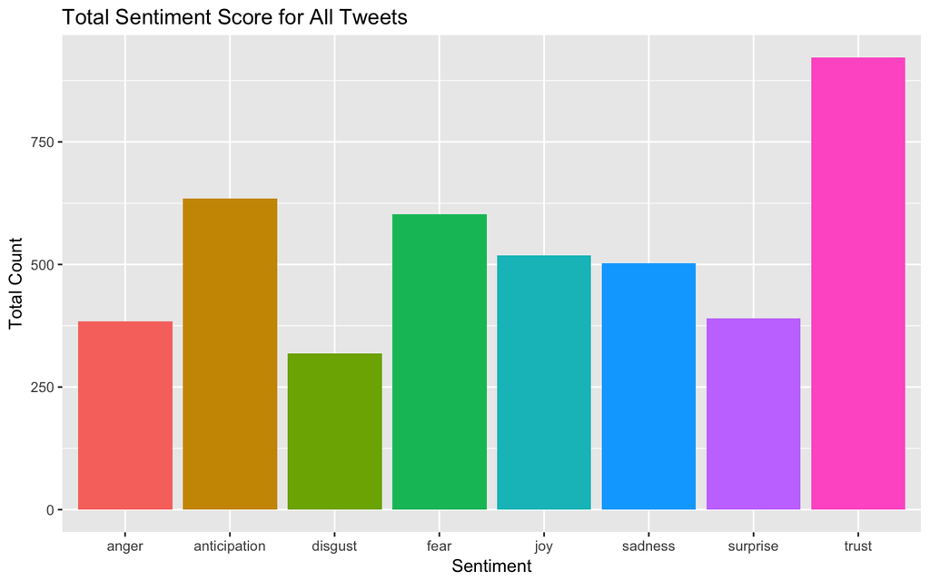

What was going on in my life that led to that spike of negativity in May 2015? (*This one I was able to figure out– it turned out to be the same time period I was going through a stressful situation at work.*)

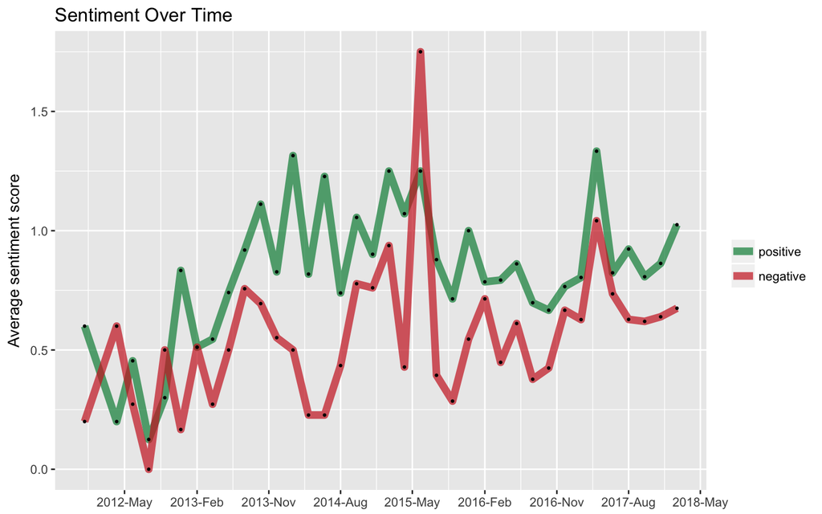

In any case, now that we’ve looked a little bit at how sentiment analysis works and what it can do, I’ll carry on in describing my planned linear analysis.

# 8 My Planned Linear Regression Model

For my linear regression model, I would like to look at how the length of a tweet is affected by various predictors. The predictors I will examine are type of tweet, anger (i.e., the tweet was characterized as angry), anticipation, disgust, fear, joy, sadness, surprise, trust, negative (overall negative as determined by sentiment analysis), overall positive, day of the week I sent out tweet, whether the tweet mentioned Donald Trump, and the month that the tweet came out. Clearly, my final model will not include all of these predictors (I only have 1000 observations), but this is where I will start.

# 9 My Planned Logistic Regression Model

For my logistic regression model, I will use `trump` (corresponding to the mention of Donald Trump in a tweet) as my outcome variable. Predictors in this case will be the number of characters in my tweet, the type of tweet, anger, anticipation, disgust, fear, joy, sadness, surprise, trust, negative, positive, month, weekday. Again, my final model will not include all these predictors, but these are the set of predictors from which I will ultimately draw a model.

# 10 Affirmation

As these data are from my own Twitter account, I am certain that it is completely appropriate for them to be shared with anyone, without any conditions. There are no concerns about privacy or security.

# 11 An Analysis: Linear Regression

## 11.1 Initial Considerations

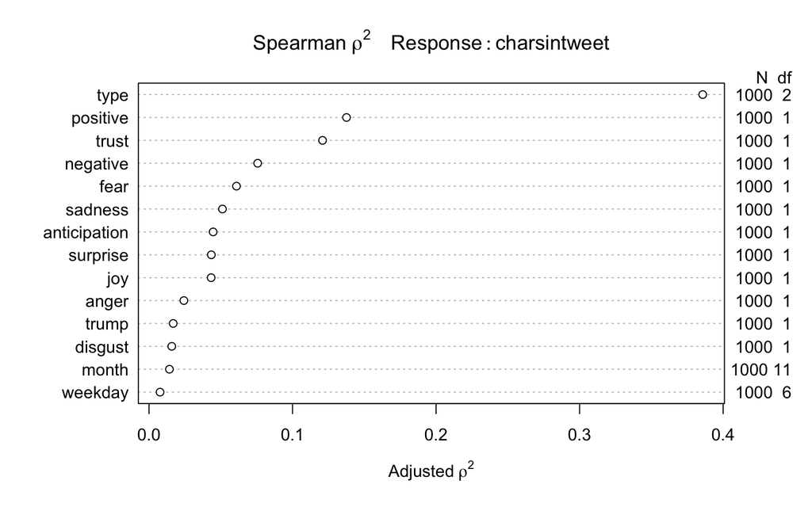

```r
plot(Hmisc::spearman2(charsintweet ~ type + anger + anticipation + disgust + fear + joy + sadness + surprise + trust + negative + positive + weekday + month + trump, data = tweets_sample))
```

The above plot provides a rationale for focusing on some variables in particular. I am going to remove `month` and `weekday` immediately, since they both use a lot of degrees of freedom and seem to have a minimal predictive punch.

I’ll run the remainder through a Lasso, to help prune down variables of interest.

## 11.2 Lasso (continuous outcome)

```r
preds <- with(tweets_sample, cbind(type, positive, trust, negative, fear, anticipation, sadness, surprise, joy, anger, disgust, trump))

lasso1 <- lars(preds, tweets_sample$charsintweet, type="lasso")
```

```r
set.seed(08291982)
tweets_sample_lassocv <- cv.lars(preds, tweets_sample$charsintweet, K=10)
```

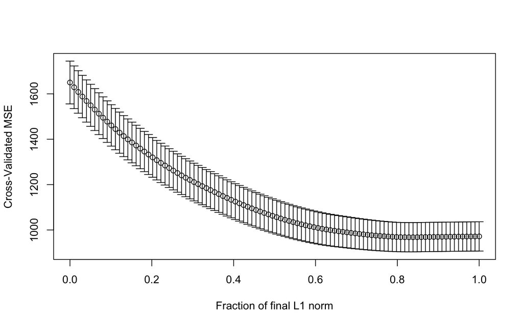

The above plot shows that the best cross-validated MSE is around 0.8 and 1.0. It turns out to be most precisely estimated at 0.83.

```r
tweets_sample.cv <- coef(lasso_p1, s=frac, mode="fraction")
round(tweets_sample.cv,3)
```

```
        type     positive        trust     negative         fear
      21.314        7.062        6.472        7.446        0.924
anticipation      sadness     surprise          joy        anger
       2.202        1.161        0.000        0.000        0.000
     disgust        trump
       0.000        7.620
```

Because Lasso doesn’t perform optimally for models with a lot of nonquantitative predictors, I am not going to actually apply these coefficients. Rather, I will just use this Lasso to eliminate the worst-performing variables and then fit a model using `lm`.

Employing this strategy, I am left with the following model skeleton:

*charsintweet ~ type + positive + trust + negative + fear + anticipation + sadness + trump*

## 11.3 Plugging Model Skeleton into `lm`

I’m going to now plug the model_skeleton into `lm`, and employ an interaction between `type` and `positive`, which were the predictors with the greatest predictive punch in my original `spearman2` analysis.

```r
mod.cont <- lm(charsintweet ~ type*positive + trust + negative + fear + anticipation + sadness + trump, data = tweets_sample)

summary(mod.cont)
```

```
Call:
lm(formula = charsintweet ~ type * positive + trust + negative +
    fear + anticipation + sadness + trump, data = tweets_sample)

Residuals:
    Min      1Q  Median      3Q     Max
-73.971 -19.061   1.659  18.750 142.863

Coefficients:
                   Estimate Std. Error t value Pr(>|t|)
(Intercept)         61.1999     2.5441  24.055  < 2e-16 ***
typereply           -6.1854     3.4911  -1.772 0.076744 .
typeRT              48.4933     3.1034  15.626  < 2e-16 ***
positive            12.9766     2.6457   4.905 1.09e-06 ***
trust                5.5843     1.6186   3.450 0.000584 ***
negative             7.2063     1.5148   4.757 2.25e-06 ***
fear                -0.6948     1.9458  -0.357 0.721130
anticipation         2.4425     1.7166   1.423 0.155092
sadness              1.5182     2.2994   0.660 0.509254
trump                8.5733     3.2300   2.654 0.008076 **
typereply:positive   7.7093     3.4209   2.254 0.024440 *
typeRT:positive    -10.2041     2.7450  -3.717 0.000213 ***
---
Signif. codes:  0 '***' 0.001 '**' 0.01 '*' 0.05 '.' 0.1 ' ' 1

Residual standard error: 28.95 on 988 degrees of freedom
Multiple R-squared:  0.4972,    Adjusted R-squared:  0.4916
F-statistic: 88.81 on 11 and 988 DF,  p-value: < 2.2e-16
```

From the above output, I conclude that Lasso has helped me develop a pretty decent model. This is hard to conclude from one model output - due to the nature of the project and need for brevity and clarity, I’ve deliberately not outlined all the OTHER models I fit that were not this successful.

This model is statistically significant and has an adjusted R-squared of 49%.

## 11.4 Validation

Although the model has already been somewhat validated as part of the Lasso analysis process, I’d like to see how it does in a new sample. Fortunately, I have a pile of 665 tweets that I deliberately set aside at the beginning, since the project required we confine ourselves to 1000 observations only, and I had 1665 observations when I started.

```r
mod.cont.pre <- predict(mod.cont, newdata=tweets_sample_test)
mod.cont.err <- tweets_sample_test$charsintweet - mod.cont.pre
mod.cont.abserr <- abs(mod.cont.err)
mod.cont.sqerr <- mod.cont.err^2
```

```r
summary(mod.cont.err)
```

```
    Min.  1st Qu.   Median     Mean  3rd Qu.     Max.
-86.7978 -20.2000   2.1938  -0.3153  18.9610 126.0293
```

So, in my test sample, my outcome is “off” by an average of 0.32 characters. This corresponds to an average absolute error of 23.2 characters, as can be seen below.

```r
summary(mod.cont.abserr)
```

```
     Min.   1st Qu.    Median      Mean   3rd Qu.      Max.
  0.06066  10.01452  19.50462  23.23678  31.00153 126.02934
```

## 11.5 Summary of Linear Model

```r
tidy(mod.cont)
```

```
                 term    estimate std.error  statistic       p.value
1         (Intercept)  61.1999482  2.544120 24.0554448 5.149634e-101
2           typereply  -6.1854239  3.491137 -1.7717508  7.674412e-02
3              typeRT  48.4932798  3.103378 15.6259671  2.358708e-49
4            positive  12.9766430  2.645664  4.9048723  1.092667e-06
5               trust   5.5843269  1.618559  3.4501837  5.838903e-04
6            negative   7.2062515  1.514754  4.7573747  2.253306e-06
7                fear  -0.6947577  1.945821 -0.3570512  7.211297e-01
8        anticipation   2.4424927  1.716605  1.4228622  1.550918e-01
9             sadness   1.5181607  2.299411  0.6602389  5.092544e-01
10              trump   8.5733317  3.230010  2.6542744  8.075639e-03
11 typereply:positive   7.7092630  3.420872  2.2535955  2.444017e-02
12    typeRT:positive -10.2041479  2.745010 -3.7173452  2.126381e-04
```

```r
glance(mod.cont)
```

```
  r.squared adj.r.squared    sigma statistic       p.value df    logLik
1 0.4971658     0.4915675 28.94701  88.80568 3.596305e-139 12 -4778.369
       AIC      BIC deviance df.residual
1 9582.738 9646.539 827874.1         988
```

Here is a listing of my linear regression equation:

`charsintweet ~ 61.2 - 6.2typereply + 48.5typeRT + 13.0 positive + 5.6trust + 7.2negative - 0.7fear` `+ 2.4anticipation + 1.5sadness + 8.6trump + 7.7typeply:positive - 10.2typeRT:positive`

The coefficients in this linear model are associated with the following 95% confidence intervals:

```r
confint(mod.cont)
```

```
                         2.5 %     97.5 %
(Intercept)         56.2074478 66.1924486
typereply          -13.0363184  0.6654706
typeRT              42.4033106 54.5832490
positive             7.7848772 18.1684088
trust                2.4081180  8.7605358
negative             4.2337471 10.1787558
fear                -4.5131738  3.1236584
anticipation        -0.9261185  5.8111038
sadness             -2.9941302  6.0304515
trump                2.2348645 14.9117988
typereply:positive   0.9962524 14.4222735
typeRT:positive    -15.5908667 -4.8174292
```

Here’s a nomogram:

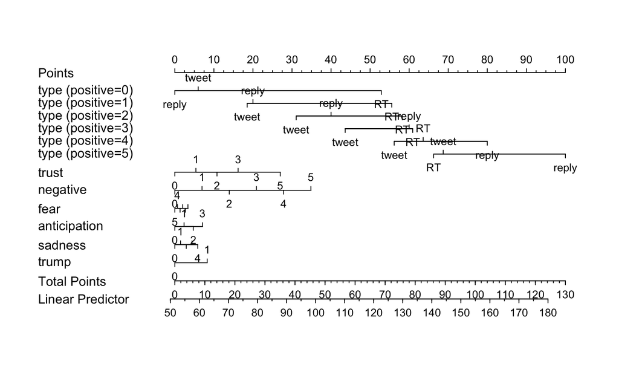

```r
plot(nomogram(mod.cont.ols))
```

Now I’ll try out my model in practice. On 06FEB2017, recalling how awful the DC Metro transit system can be, I tweeted the following:

*Why does @wmata suck so bad? I used to ride every day until I got so fed up I just decided I will fight the traffic and drive to work*

I should point out that this particular tweet was not part of the random sample of 1000 I used to build the model, so it can really be considered new data to test my model on. How does sentiment analysis handle this little gem?

```r
get_nrc_sentiment("Why does @wmata suck so bad? I used to ride every day until I got so fed up I just decided I will fight the traffic and drive to work")
```

```
  anger anticipation disgust fear joy sadness surprise trust negative
1     2            0       1    2   0       1        0     0        3
  positive
1        0
```

These emotional scores make sense intuitively; I was going for a negative sentiment at the time. Now I should have enough to go on for a prediction.

```r
mod.cont.prediction <- data_frame(type = "tweet", positive = 0, trust = 0, negative = 3, fear = 2, anticipation = 0, sadness = 1, trump = 0)
predict(mod.cont, newdata = mod.cont.prediction, interval = "prediction", level = 0.95)
```

```
       fit      lwr      upr
1 82.94735 25.54799 140.3467
```

# 12 An Analysis: Logistic Regression

## 12.1 Initial Considerations

First, I would like to share a motivating graphic for my logistic analysis. In looking at my tweets, I was curious to see what was most on my mind. What has been @McDonnellJack’s primary twitter focus? Medicine (my veritable bread and butter)? Naval service (since I was in the Navy on Guam for years)? My family and friends?

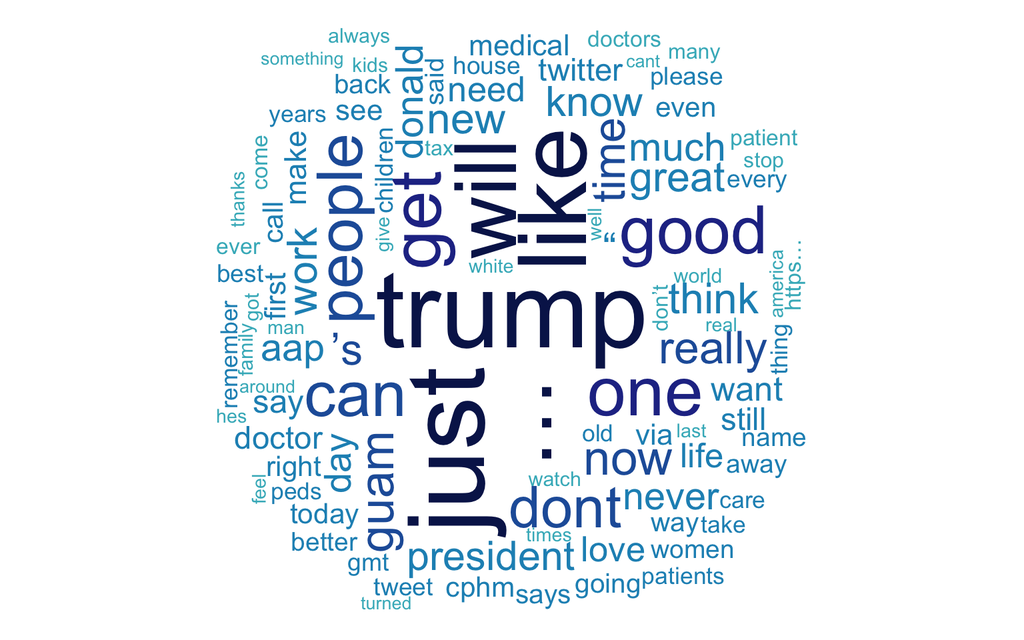

```r
pal <- brewer.pal(9,"YlGnBu")
pal <- pal[-(1:4)]
set.seed(123)
wordcloud(words = wordCorpus, scale=c(5,0.1), max.words=100, random.order=FALSE,
          rot.per=0.35, use.r.layout=FALSE, colors=pal)
```

Oh . . . not sure I expected that.

With this self-insight as a primary motivator, I’ll turn to building a logistic regression model.

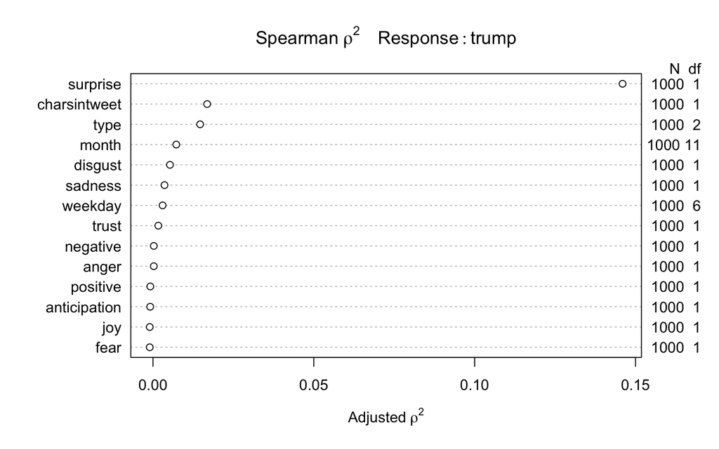

```r
plot(Hmisc::spearman2(trump ~ charsintweet + type + anger + anticipation + disgust + fear + joy + sadness + surprise + trust + negative + positive + month + weekday, data = tweets_sample))
```

What a surprise! `Surprise` tops my list of variables with the greatest predictive punch, as estimated by this `spearman2` plot.

As before, I am going to remove `month` and `weekday` immediately, since they both use a lot of degrees of freedom and seem to have minimal predictive effect.

Similar to before, with the continuous-outcome model, I will run a Lasso to prune these down further. This may seem like an unusual strategy to employ, given a binary outcome, but what I found was that this approach yielded more helpful models than some of the other strategies I tried (best subsets, stepwise selection technique). I am not including all these attempts for the sake of brevity.

## 12.2 Lasso (binary outcome)

```r
tweets_sample_lassocv.log <- cv.lars(preds.log, tweets_sample$trump, K=10)
```

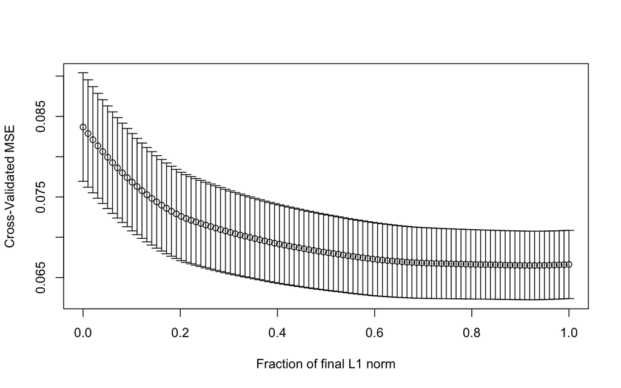

Visually, the cross-validated MSE seems to be minimized at around 0.8-0.9. It turns out to occur at exactly 0.85.

```r
tweets_sample_log.cv <- coef(lasso2, s=frac, mode="fraction")
round(tweets_sample_log.cv,3)
```

```
charsintweet     surprise         type        anger anticipation
       0.001        0.281        0.018        0.000       -0.045
     disgust         fear          joy      sadness        trust
      -0.003       -0.027       -0.084        0.000        0.011
    negative     positive
      -0.002       -0.013
```

The Lasso analysis has helped me determine that the worst-performing predictors are `charsintweet`, `anger`, and `sadness`.

Given this, I am left with the following model skeleton to plug into a `lrm` logistic regression.

*trump ~ surprise + type + anticipation + disgust + fear + joy + trust + negative + positive*

## 12.3 Plugging Model Skeleton into `lrm`

```r
d <- datadist(tweets_sample)
options(datadist = "d")

mod.log<- lrm(trump ~ surprise + type + anticipation + disgust + fear + joy + trust + negative + positive, data = tweets_sample, x = TRUE, y = TRUE)
mod.log
```

```
Logistic Regression Model

 lrm(formula = trump ~ surprise + type + anticipation + disgust +
     fear + joy + trust + negative + positive, data = tweets_sample,
     x = TRUE, y = TRUE)

                       Model Likelihood     Discrimination    Rank Discrim.
                          Ratio Test           Indexes           Indexes
 Obs          1000    LR chi2     184.23    R2       0.367    C       0.844
  0            908    d.f.            10    g        1.690    Dxy     0.689
  1             92    Pr(> chi2) <0.0001    gr       5.420    gamma   0.697
 max |deriv| 2e-10                          gp       0.117    tau-a   0.115
                                            Brier    0.058

              Coef    S.E.   Wald Z Pr(>|Z|)
 Intercept    -3.9340 0.4724 -8.33  <0.0001
 surprise      3.0508 0.2931 10.41  <0.0001
 type=reply    1.3675 0.5198  2.63  0.0085
 type=RT       1.3461 0.4734  2.84  0.0045
 anticipation -0.6517 0.3246 -2.01  0.0447
 disgust      -0.0041 0.3007 -0.01  0.9892
 fear         -0.5506 0.2677 -2.06  0.0397
 joy          -1.5635 0.4135 -3.78  0.0002
 trust         0.5553 0.2153  2.58  0.0099
 negative     -0.0177 0.2032 -0.09  0.9305
 positive     -0.3891 0.2083 -1.87  0.0618
```

This looks like a decent model - it is statistically significant and has a decent Nagelkerke R2 and good C statistic. Of course, to get a sense of the “real-world” performance of a model, it is helpful to validate.

```r
validate(mod.log, B = 100)
```

```
          index.orig training    test optimism index.corrected   n
Dxy           0.6884   0.7092  0.6748   0.0344          0.6540 100
R2            0.3666   0.3856  0.3465   0.0391          0.3275 100
Intercept     0.0000   0.0000 -0.1387   0.1387         -0.1387 100
Slope         1.0000   1.0000  0.9197   0.0803          0.9197 100
Emax          0.0000   0.0000  0.0452   0.0452          0.0452 100
D             0.1832   0.1943  0.1722   0.0221          0.1611 100
U            -0.0020  -0.0020  0.0011  -0.0031          0.0011 100
Q             0.1852   0.1963  0.1711   0.0252          0.1600 100
B             0.0584   0.0568  0.0599  -0.0030          0.0614 100
g             1.6900   1.8360  1.6785   0.1575          1.5325 100
gp            0.1168   0.1204  0.1146   0.0058          0.1110 100
```

My corrected C-statistic (obtained from the Dxy above) becomes 0.83.

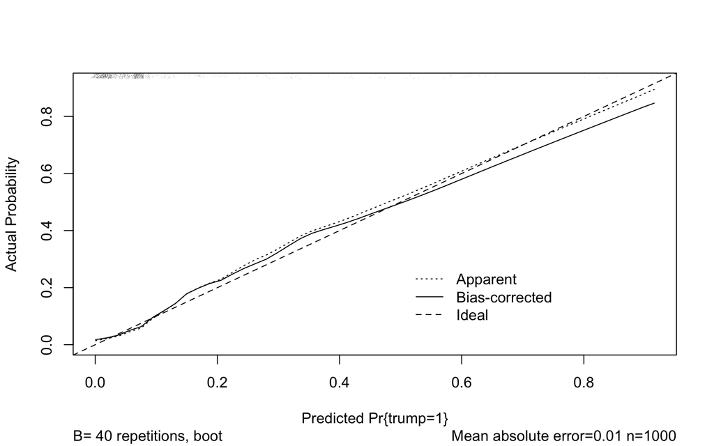

```
n=1000   Mean absolute error=0.01   Mean squared error=0.00017
0.9 Quantile of absolute error=0.017
```

```r
plot(calibrate(mod.log))
```

My calibration in this model looks pretty decent as well.

Another check is to look at the ROC curve of this model considering ALL of the original 1665 tweets I started with. The discrimination of the model is still pretty good.

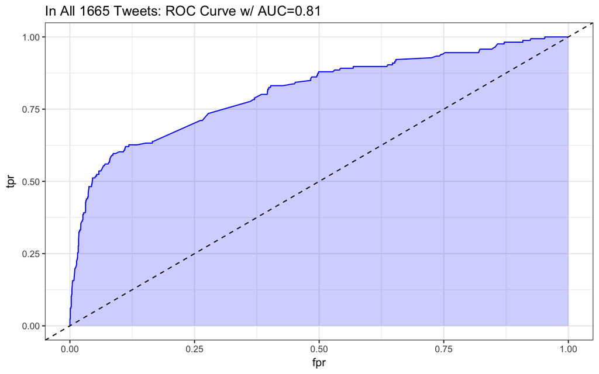

```r
prob <- predict(mod.log, tweets, type="fitted")
pred <- prediction(prob, tweets$trump)
perf <- performance(pred, measure = "tpr", x.measure = "fpr")
auc <- performance(pred, measure="auc")

auc <- round(auc@y.values[[1]],3)
roc.data <- data.frame(fpr=unlist(perf@x.values),
                       tpr=unlist(perf@y.values),
                       model="GLM")

ggplot(roc.data, aes(x=fpr, ymin=0, ymax=tpr)) +
    geom_ribbon(alpha=0.2, fill = "blue") +
    geom_line(aes(y=tpr), col = "blue") +
    geom_abline(intercept = 0, slope = 1, lty = "dashed") +
    labs(title = paste0("In All 1665 Tweets: ROC Curve w/ AUC=", auc)) +
    theme_bw()
```

## 12.4 Summary of Logistic Model

```r
mod.log
```

```
Logistic Regression Model

 lrm(formula = trump ~ surprise + type + anticipation + disgust +
     fear + joy + trust + negative + positive, data = tweets_sample,
     x = TRUE, y = TRUE)

                       Model Likelihood     Discrimination    Rank Discrim.
                          Ratio Test           Indexes           Indexes
 Obs          1000    LR chi2     184.23    R2       0.367    C       0.844
  0            908    d.f.            10    g        1.690    Dxy     0.689
  1             92    Pr(> chi2) <0.0001    gr       5.420    gamma   0.697
 max |deriv| 2e-10                          gp       0.117    tau-a   0.115
                                            Brier    0.058

              Coef    S.E.   Wald Z Pr(>|Z|)
 Intercept    -3.9340 0.4724 -8.33  <0.0001
 surprise      3.0508 0.2931 10.41  <0.0001
 type=reply    1.3675 0.5198  2.63  0.0085
 type=RT       1.3461 0.4734  2.84  0.0045
 anticipation -0.6517 0.3246 -2.01  0.0447
 disgust      -0.0041 0.3007 -0.01  0.9892
 fear         -0.5506 0.2677 -2.06  0.0397
 joy          -1.5635 0.4135 -3.78  0.0002
 trust         0.5553 0.2153  2.58  0.0099
 negative     -0.0177 0.2032 -0.09  0.9305
 positive     -0.3891 0.2083 -1.87  0.0618
```

My equation for the logistic regression model, rounded to one decimal place, is as follows:

`logit(trump) ~ -3.9 + 3.1surprise + 1.4type=reply + 1.3type=RT -0.7anticipation - 0.0disgust - 0.6fear` `-1.6joy + 0.6trust - 0.0negative - 0.4positive`

Remember that this is on a log odds scale. For the coefficients given in terms of an odds ratio, see the output below:

```r
summary(mod.log)
```

```
             Effects              Response : trump

 Factor          Low High Diff. Effect      S.E.    Lower 0.95
 surprise        0   3     3       9.152400 0.87938    7.428900
  Odds Ratio     0   3     3    9437.100000      NA 1683.900000
 anticipation    0   1     1      -0.651680 0.32464   -1.288000
  Odds Ratio     0   1     1       0.521170      NA    0.275830
 disgust         0   4     4      -0.016310 1.20290   -2.373900
  Odds Ratio     0   4     4       0.983820      NA    0.093113
 fear            0   1     1      -0.550570 0.26772   -1.075300
  Odds Ratio     0   1     1       0.576620      NA    0.341190
 joy             0   1     1      -1.563500 0.41347   -2.373900
  Odds Ratio     0   1     1       0.209400      NA    0.093119
 trust           0   1     1       0.555300 0.21526    0.133400
  Odds Ratio     0   1     1       1.742500      NA    1.142700
 negative        0   1     1      -0.017714 0.20323   -0.416050
  Odds Ratio     0   1     1       0.982440      NA    0.659650
 positive        0   1     1      -0.389130 0.20832   -0.797440
  Odds Ratio     0   1     1       0.677640      NA    0.450480
 type - tweet:RT 3   1    NA      -1.346100 0.47335   -2.273800
  Odds Ratio     3   1    NA       0.260260      NA    0.102920
 type - reply:RT 3   2    NA       0.021414 0.32047   -0.606690
  Odds Ratio     3   2    NA       1.021600      NA    0.545150
 Upper 0.95
  1.0876e+01
  5.2889e+04
 -1.5385e-02
  9.8473e-01
  2.3413e+00
  1.0395e+01
 -2.5841e-02
  9.7449e-01
 -7.5310e-01
  4.7090e-01
  9.7720e-01
  2.6570e+00
  3.8062e-01
  1.4632e+00
  1.9171e-02
  1.0194e+00
 -4.1833e-01
  6.5815e-01
  6.4952e-01
  1.9146e+00
```

The most intense predictor in a tweet mentioning Trump is the tweet expressing the emotion of “surprise,” by an incredibly large factor (odds ratio 9437.1). This was reflected in the spearman2 plot earlier as well. Apparently, my overwhelming sentiment towards the current presidency is one of sheer incredulity.

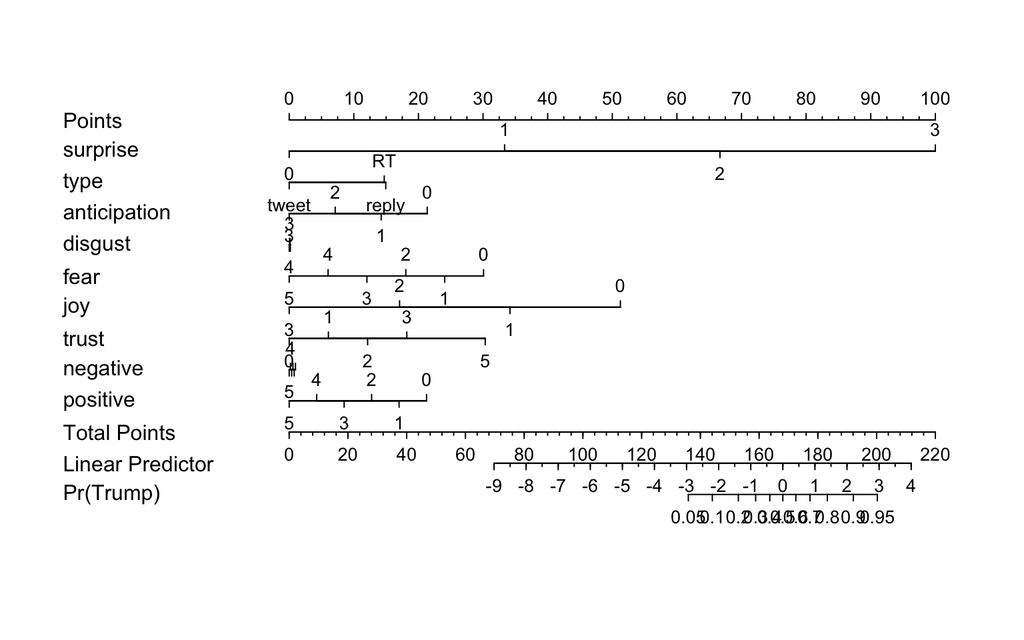

```r
plot(nomogram(mod.log, fun=plogis,
              fun.at=c(0.05, seq(0.1, 0.9, by=0.1), 0.95),
              funlabel="Pr(Trump)"))
```

Let’s try out our nomogram. On 23DEC2017, I tweeted the following in reply to a tweet from @JasonMillerinDC:

`@JasonMillerinDC @POTUS What to do when you just saved yourself 11 million in taxes? Go golfing at taxpayers expense!`

As before, this tweet was picked from the 665 I set aside at the beginning and did not use to build my model. What sentiment does this tweet communicate?

```r
get_nrc_sentiment("@JasonMillerinDC @POTUS What to do when you just saved yourself 11 million in taxes? Go golfing at taxpayers expense!")
```

```
  anger anticipation disgust fear joy sadness surprise trust negative
1     0            0       0    0   0       0        0     0        0
  positive
1        0
```

Apparently the level of sarcasm in my tweet was too subtle for the sentiment analysis to detect. The calculation, using the nomogram as a guide, goes like this:

0 points for surprise + 15 for reply + 20 points for anticipation + 30 for fear + 50 for joy + 0 for trust + 20 for positive gives us a total score of 135. Scanning down visually, this equates to a linear predictor score of around -3, and a Pr(Trump) of around 0.05. In this case, the prediction using our model was accurate - the tweet was predicted as having a very low probability of “Trump” and in reality “Trump” was not in the tweet (although I was actually speaking about him.)

```r
mod.log.prediction <- data_frame(type = "reply", surprise = 0, anticipation = 0, disgust = 0, fear = 0, joy = 0, trust = 0, negative = 0, positive = 0)
predict(mod.log.glm, newdata = mod.log.prediction, type = "response")
```

```
         1
0.07132869
```

Using R to calculate the probability for this example (as opposed to visually checking the nomogram) gives a very similar answer - 0.07.

# 13 Thoughts on the Process

Data science projects always seem easier to me in theory than practice. We learn the code in class, and it is clearly laid out in the Course Notes, so isn’t it really trivial to replicate a type of analysis in R? The reality is that this isn’t the hard part of doing a project. The hard part is deciding between multiple options, all of which have merit, with no idea of what the “best” choice is.

One thing I wish I’d known at the start was how much tidying there was left to do. After turning in my project proposal, which did require some tidying, I was lulled into a false sense of complacency. In actuality, I had many more wrangling steps to perform; I just didn’t realize it yet.

The most confusing part of the project for me was figuring out how to build an interesting linear model, given that the only continuous outcome I had in my dataset was a variable describing the number of characters in a tweet. I’m not convinced I completely succeeded in this – to me, my logistic model is much more interesting. The most useful thing I learned throughout this process was how to do a Lasso, which seemed very theoretical to me when I read about it in the course notes.

I always hate projects when I’m doing them, but afterwards I look back and realize that the process really did help me hone my skills. This project is a perfect example of that.

Jack McDonnell

2018-03-23 11:50:11